# Running the MetaRange Model for Mammals

Step-by-step guide

# Introduction

This tutorial explains how to run the metaRange model framework for mammal species. It walks through formatting and loading input data, setting up the simulation, running the simulation and what outputs can be expected.

> To run our approach, input directories (dirinput) and output directories (dirout) were previously created to save the input files and respective model output raster files and plots.

First tings first! In order to use metaRange to model mammal species populations we need to decide:

1. Our **target biome**
2. Our **target region**
3. Our **target species**

> **Note**

> We can set multiple target species but only one target biome or region as these will be used in the names used to save output files.

```r
# select target biome
target_biome <- "Boreal Forests Taiga"

# select target region
target_region <- "Sweden"

# select target species
target_species <- "Alcesalces"

# import trait dataframe
species_traits <- read.csv(file.path(dirinput, "metaRangeSpeciesDataframe.csv"))
```

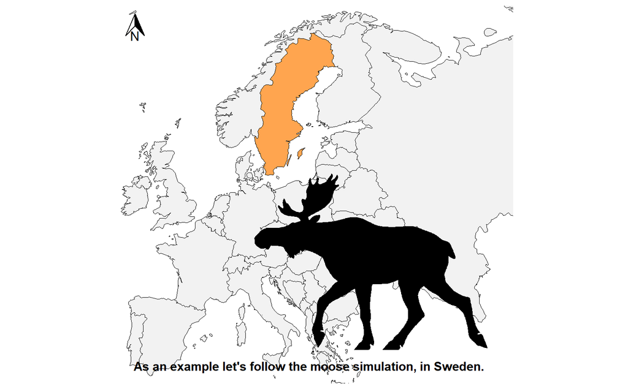

# Model Inputs

A complete introduction to the metaRange framework can be found [here](https://metarange.github.io/metaRange/articles/A01_intro.html).

To run the model simulation two external inputs are required:

- **Landscapes** - raster files containing the environment or hypothetical scenario in which species will be modeled (e.g. species habitat suitability map);
- **Species Traits Dataframe** - a dataframe containing species specific trait information which will act as starting values for the model (e.g. species abundance or reproduction rates).

## Landscapes

To re-create the landscapes used here to run the metaRange model several steps should be followed:

**1. Get global suitability landscapes** - The first step is to acquire global habitat suitability landscapes from the SRIT Database, available [here](https://drive.google.com/drive/u/0/folders/1lDlEWq9uGEi2z9xe_R2klHkQ4cRDHj3r). These landscapes provide a habitat suitability index for species worldwide.

**2. Build a dynamic landscape** - For this example, we assume that the habitat suitability for the target species declines 1% per year over a 25-year simulation period. To represent this change, we will create 25 layers, each representing a year with suitability values decreasing over time. This will create a dynamic landscape, meaning: the landscape changes over time.

```r
# function to duplicate raster layers as we see fit
duplicate_layers <- function(raster, times) {
  replicated <- list()

  # layer 1: Original raster
  replicated[[1]] <- raster

  # layer 2: Exact copy of original raster
  replicated[[2]] <- raster

  # layers 3 to end - suitability decreases progressivly by 1%
  new_layer <- raster
  for (i in 3:times) {
    new_layer <- new_layer * 0.99  # Reduce by 1% each time
    replicated[[i]] <- new_layer
  }
  return(rast(replicated))
}
```

**3. Crop the global landscape to the target region** - Since we are modelling species within a specific biome and continent, we need to crop our global landscapes to the relevant area. For that we can use the rnaturalearth packages functions to retrieve regions boundaries and crop landscapes raster files. Here we will retrieve Sweden’s political borders (SW).

> This approach can be scaled up to crop ecoregion’s shapefiles, from [Dinerstein et al. 2017](https://academic.oup.com/bioscience/article/67/6/534/3102935), by continental boundaries, also available in `rnaturalearth` package, and use those cropped raster as landscapes to model our target species. - code already available [here](https://github.com/andrepsilvadev/NatPoKe/blob/dev/src/inputFiles.R).

```r
# Swedish political boundaries
SW <- ne_countries(scale = "large", country = target_region, returnclass = "sv")

# loop through each raster file
for (r in raster_files) {
  # READ the raster
  sp_raster <- rast(r)

  # TRANSFORM values from 0-100 to 0-1
  r_rescaled <- sp_raster/100

  # CROP the raster to the bounding box
  cropped_raster <- terra::crop(r_rescaled, SW)

  # MASK the raster to the bounding box (to avoid weird finland land masses)
  masked_raster <- terra::mask(cropped_raster, SW)

  # DUPLICATE the layers 25 times
  duplicated_raster <- duplicate_layers(masked_raster, times = 25)

  # SAVE processed raster
  output_path <- file.path(dirinput, tools::file_path_sans_ext(basename(r)))
  writeRaster(duplicated_raster, paste0(output_path, "_cropped_modified.tif"), overwrite = TRUE)

  # remove unecessary objects
  rm(sp_raster, r_rescaled, cropped_raster, masked_raster, duplicated_raster, output_path)
}
```

**4. Project landscapes to appropriate coordinate system** - To ensure accurate distance measurements, our dynamic landscapes need to projected to a adequate projected coordinates systems (crs), depending on our study region, in meters or kilometers. The conversion from meters to kilometers or vice.verse needs to be accounted for in this step. The processed rasters to an inputs folder so they can be used in the metaRange model next.

```r
# list cropped and dynamic landscapes created the last step
landscape_SW <- list.files(path = dirinput,
                            pattern = paste0(target_species, "_suitability_cropped_modified\\.tif$", collapse = "|"),
                            full.names = TRUE)

# gor through each landscape
for (landscape in landscape_SW) {

  # LOAD raster
  r <- rast(landscape)

  # REPROJECT to SWEREF99 TM (EPSG:3006)
  r_utm <- project(r, "EPSG:3006")

  # convert to rasterStack
  r_raster <- stack(r_utm)

  # get original CRS
  orig_crs <- crs(r_utm)

  # RESCALE extent (divide by 1000 to convert meters to kilometers)
  extent(r_raster) <- extent(r_raster) / 1000

  # Modify CRS to indicate the new unit is kilometers
  new_crs <- gsub("UNIT\\[\"metre\",1\\]", "UNIT[\"kilometre\",1000]", orig_crs)

  # Apply modified CRS
  crs(r_raster) <- new_crs

  # Convert back to SpatRaster while keeping all layers
  r_km <- rast(r_raster)

  # output filename
  output_filename <- gsub("\\.tif$", "_reprojectedKm.tif", landscape)

  # save reprojected raster
  writeRaster(r_km, output_filename, overwrite = TRUE)

  # remove unecessary objects
  #rm(r, r_utm, r_raster, orig_crs, new_crs, r_km, output_filename)
}
```

## Species Traits Dataframe

Species trait data are scattered across several sources, from online databases to research articles, making it very hard to find.

As such to address this data scarcity, and combine enough trait data for our target species, we integrated various datasets from multiple sources and estimated the remaining ones from reported equations. The code used for data collection can be accessed [here](https://github.com/andrepsilvadev/SRIT-database/blob/dev/src/mammalTraits.R). And the construction of a correctly formatted dataframe for the metaRange model [here](https://github.com/andrepsilvadev/NatPoKe/blob/dev/src/mammalMetaRangeSpeciesDataframe.R).

| Trait | Description | Units | Database of origin |
| --- | --- | --- | --- |
| abundance | number of individuals per cell in the landscape | individuals/cell | Santini et al. 2022 |
| reproductionRate | number of individuals per cell in the landscape (net reproduction rate) | inidividuals | estimated by multiplying the litter size by the years of reproductive success |
| carryingCapacity | maximum Number of individuals in a grid cell | individuals/cell | Santini et al. 2022 |
| dispersalDistance | mean dispersal distance | cells | based on species trophic level & estimated from reported equations in Schloss et al. 2012 and BodyMass values from Pantheria and Phylacine |
| maxDispersalDistance | maximum long dispersal distances | cells | based on species trophic level & estimated from reported equations in Schloss et al. 2012 and BodyMass values from Pantheria and Phylacine |
| yearlySurvivalRate | annual probability of survival | no units | Estimated according to: 1 - metabolic mortality rate (from McCarthy et al. 2008) |

For our target species, the moose, this resulted in:

|  | Index | Species | Family | Order | TrophicLevel | Taxa | BodyMass | CellResolution | ModellingRes | initialAbundance | carryingCapacity | reproductionRate | dispersalDistance | dispersalMaxDistance | yearlySurvivalRate |
| --- | --- | --- | --- | --- | --- | --- | --- | --- | --- | --- | --- | --- | --- | --- | --- |
| 1 | 3 | Alcesalces | CERVIDAE | ARTIODACTYLA | Herbivore | Mammal | 356.998 | 9.467608994704 | 10 | 59 | 353 | 30.8900295890411 | 10 | 16 | 0.7699440053940468 |

> Warnings!

> There should always exist a landscape file for all species contained in the Species traits Dataframe.

> The Species Trait dataframe should only have species without spaces between the genus and species names.

# Model simulation

## Step 1 - Setting up the simulation

After setting up our modelling targets and the model’s external inputs, the simulation needs to be initialized and reporting can (and should) be enabled. Setting the verbosity to zero, means the simulation will run silent with no warnings or updates, 1 will give us progress updates and 2 will go into the debugging mode.

```r
set_verbosity(2L)
options(scipen = 999)
set.seed(1)
sim_name <- paste0("mammals_", Sys.Date())
```

## Step 2 - Load Landscape data

The landscapes to use in the simulation (created in the previous sections) are loaded using the `terra::sds()` function and as such they should be in the `SpatRaster` format. All layers should have the same resolution and extent for the same species. Each layer in the loaded landscape will represent a timestep in the simulation, so there should be as many layers in our landscape as timesteps.

```r
sim_env <- sds(list.files(dirinput,
                          pattern = "_cropped_modified_reprojectedKm.tif", full.names = TRUE))
```

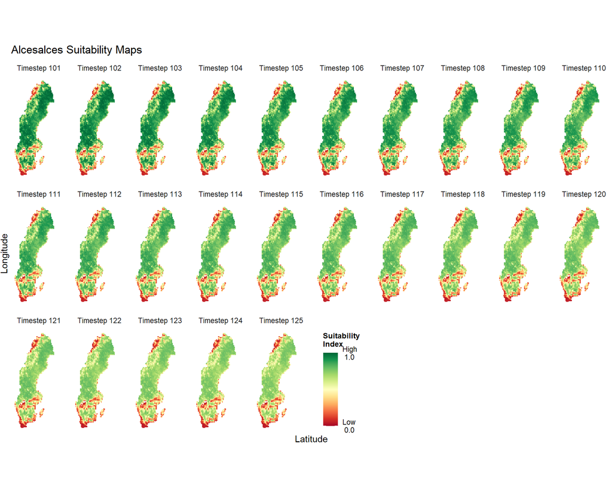

## Step 3 - Create a simulation object

After the landscapes for our target species are loaded, the simulation object needs to be created, with landscapes being the only argument the function needs.

```r
sim <- create_simulation(sim_env)
```

```
## class       : SpatRasterDataset
## subdatasets : 7
## dimensions  : 118, 63 (nrow, ncol)
## nlyr        : 25, 25, 25, 25, 25, 25, 25
## resolution  : 13.06632, 13.16876  (x, y)
## extent      : 666919.3, 667742.5, 6907278, 6908832  (xmin, xmax, ymin, ymax)
## coord. ref. : SWEREF99 TM
## source(s)   : Alcesalces_suitability_cropped_modified_reprojectedKm.tif, Canislupus_suitability_cropped_modified_reprojectedKm.tif, Cervuselaphus_suitability_cropped_modified_reprojectedKm.tif, Damadama_suitability_cropped_modified_reprojectedKm.tif, Lynxlynx_suitability_cropped_modified_reprojec…
## names       : Alcesalces_suitability_cropped_modified_reprojectedKm, Canislupus_suitability_cropped_modified_reprojectedKm, Cervuselaphus_suitability_cropped_modified_reprojectedKm, Damadama_suitability_cropped_modified_reprojectedKm, Lynxlynx_suitability_cropped_modified_reprojectedKm, Rangifert…
```

## Step 4 - Add the timesteps

To incorporate a burn-in period into our simulation we need to set up with an initial phase of 100 steps (which are all the same) followed by sequential time steps. In total this simulation had 125 timesteps.

```r
sim$set_time_layer_mapping(c(rep(1, 100), seq_len(min(nlyr(sim_env)))))
```

```
## number of time steps: 125
```

```
## time step layer mapping: 1, 1, 1, 1, 1, 1, 1, 1, 1, 1, 1, 1, 1, 1, 1, 1, 1, 1, 1, 1, 1, 1, 1, 1, 1, 1, 1, 1, 1, 1, 1, 1, 1, 1, 1, 1, 1, 1, 1, 1, 1, 1, 1, 1, 1, 1, 1, 1, 1, 1, 1, 1, 1, 1, 1, 1, 1, 1, 1, 1, 1, 1, 1, 1, 1, 1, 1, 1, 1, 1, 1, 1, 1, 1, 1, 1, 1, 1, 1, 1, 1, 1, 1, 1, 1, 1, 1, 1, 1, 1, 1,…
```

## Step 5 - Add the Species & Traits

From this point forward the code syntax will switch to R6 package, which is used by the metaRange function.

After the simulation is created, we can now add our `target_species`. Traits are also added at this point, with some being set as `population level = TRUE` meaning that the trait is stored as a matrix and others set as `population_level = FALSE` meaning they will be a single value for that species.

```r
for (i in seq_len(nrow(species_traits))) {
  this_species <- species_traits[["Species"]][i]

  # "register" the species with the simulation
  sim$add_species(this_species)

  # add traits that need to be stored at the population level
  sim$add_traits(
    species = this_species,
    population_level = TRUE,

      "abundance" = species_traits[["initialAbundance"]][i],
      "abundance_before" = 0,
      "reproductionRate" = species_traits[["reproductionRate"]][i],
      "carryingCapacity" = species_traits[["carryingCapacity"]][i],
      "yearlySurvivalRate" = species_traits[["yearlySurvivalRate"]][i])

  # add traits that are the same for all populations of a species
  sim$add_traits(
    species = this_species,
    population_level = FALSE,
      "dispersalDistance" =  species_traits[["dispersalDistance"]][i],
      "maxReproductionRate" = species_traits[["reproductionRate"]][i],
      "maxCarryingCapacity" = species_traits[["carryingCapacity"]][i],

  # simple kernel, but you can use any function / dispersal kernel
      "dispersalKernel" = calculate_dispersal_kernel(
        max_dispersal_dist = as.integer(species_traits[["dispersalMaxDistance"]][i]),
        kfun = negative_exponential_function,
        mean_dispersal_dist = species_traits[["dispersalDistance"]][i],
      )
    )
}
```

We can check what each trait looks like, for the moose, by plotting them. The abundance was set as a matrix and dispersal distance as a single value.

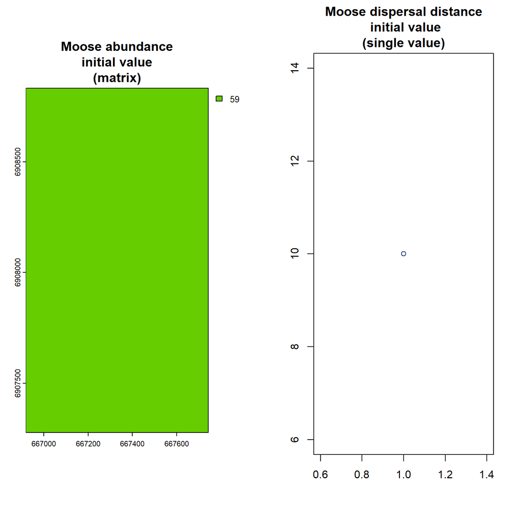

```r
par(mfrow = c(1,2))
plot(sim$Alcesalces, "abundance",
     main = "Moose abundance\ninitial value\n(matrix)",
     col = "chartreuse3")
plot(sim$Alcesalces, "dispersalDistance",
     main ="Moose dispersal distance\n initial value\n(single value)",
     xlab = "", ylab = "")
```

## Step 6 - Add Global Variables

A list of global variables can be created to track species populations throughout the simulation and allow easy model diagnostics in the end. Here we added global variables for the total number of individuals (n_abundance), mean number of individuals per cell (mean_abundance), mean reproduction rate (mean_rrate), mean carrying capacity (mean_ccap) and total number of occupied cells (n_occupied).

```r
species_names <- sim$species_names()
species_sum_abundance <- vector("list", length(species_names))
names(species_sum_abundance) <- species_names
for (i in species_names) {
  species_sum_abundance[[i]] <- list(
  "n_abundance" = vector("numeric", sim$number_time_steps),
  "mean_abundance" = vector("numeric", sim$number_time_steps),
  "mean_rrate" = vector("numeric", sim$number_time_steps),
  "mean_ccap" = vector("numeric", sim$number_time_steps),
  "n_occupied" = vector("numeric", sim$number_time_steps)
  )
  }

do.call(sim$add_globals, species_sum_abundance)
```

For our example, the total number of individuals (n_abundance) will useful later on for us to calculate impact and recovery metrics, for each species or for the taxa, and as such we can save those results as .csv as explained further in Step 9.

## Step 7 - Adding the processes

Adding processes to each species is the next step in our pipeline. A process describes how a species interacts with its environment, and these can be added through `add_process()` function. This function needs to use as arguments the `species` (as a vector of target species names), the `process_name` (for us to know what is being done) and the `process_fun` (for the model to know what to do). This step also relies on the `execution priority`, which is a number indicating the priority of that process in a queue. The processes are executed in an order, which means a smaller the number, will determine that the process is to be executed earlier on the queue.

The processes also make use of the `self` keyword. It refers to the species that the process is attached to, allowing the function to access the species traits, modify them and also access their environment,

### Suitability influence on population dynamics

Suitability influences species traits. To account for this, we incorporated a process that simultaneously adjusts both the reproductive rates and carrying capacities of each species, ensuring they respond dynamically to habitat suitability for each cell.

```r
# Suitability influence on the environment
sim$add_process(
  species = species_names,
  process_name = "suitability_influence_population_parameter",
  process_fun = function() {
    species_suitability_name <- paste0(self$name, "_suitability_cropped_modified_reprojectedKm")

    self$traits[["carryingCapacity"]] <-
      self$traits[["maxCarryingCapacity"]] * self$sim$environment$current[[species_suitability_name]]

    self$traits[["reproductionRate"]] <-
      self$traits[["maxReproductionRate"]] * self$sim$environment$current[[species_suitability_name]]
  },
  execution_priority = 1
)
```

### Demography

To include local population’s dynamics was included in this model through the **Beverton & Holt model**, a density-dependent population dynamics model where population size stabilizes as resource limitations increase competition among individuals. Considering the large macroecological approach used here, this model was used as an alternative to more stage dynamics focused models, which are already included in the metaRange package.

```r
# Demographic processes (Beverton & Holt)
sim$add_process(
  species = species_names,
  process_name = "demography_BevertonHolt",
  process_fun = function(){
    self$traits[["abundance"]] <- beverton_holt(abundance = self$traits[["abundance"]],
                                                reproduction_rate = self$traits[["reproductionRate"]],
                                                carrying_capacity = self$traits[["carryingCapacity"]],
                                                survival_rate = self$traits[["yearlySurvivalRate"]])
  },
  execution_priority = 2
)
```

### Dispersal

Additionally, here we introduce **dispersal change** within the dispersal process to track population movements in the landscape (see Dispersal change section bellow).

```r
# Dispersal
sim$add_process(
  species = species_names,
  process_name = "dispersal_process",
  process_fun = function() {
    # save the number of individuals before dispersing
    self$traits[["abundance_before"]] <- trunc(self$traits[["abundance"]])
    # weighted dispersal
    # i.e. individuals disperse more likely into more suitable cells
    self$traits[["abundance"]] <- dispersal(
      abundance = self$traits[["abundance"]],
      weights = self$sim$environment$current[[paste0(self$name, "_suitability_cropped_modified_reprojectedKm")]],
      dispersal_kernel = self$traits[["dispersalKernel"]])
    # calculate the dispersal change
    self$traits[["dispersal_change"]] <- self$traits[["abundance"]] - self$traits[["abundance_before"]]
  },
  execution_priority = 3
)
```

### Other processes

**Truncate**

To ensure that only whole individuals occur in our landscape we use the `truncate` function to eliminate the possibility of 0.5 individuals.

```r
# Ensure whole individuals
sim$add_process(
  process_name = "truncate",
  process_fun = function() {
    # just because there is nothing in reality like 0.5 individuals
    for (i in self$globals[["alive_species"]]) {
      self[[i]]$traits[["abundance"]] <- trunc(self[[i]]$traits[["abundance"]])
    }
  },
  execution_priority = 5
)
```

**Tracking statistics**

We also introduce tracking statistics, based on the global variables defined in a previous step and remove species from the process queue in case they go extinct.

```r
# Tracking statistics
sim$add_process(
  process_name = "track_stats",
  process_fun = function() {
    for (i in self$globals[["alive_species"]]) {
      current_abu <- sum(self[[i]]$traits[["abundance"]], na.rm = TRUE) # sum up all abundances across cells
      # remove species from future process queue if extinct
      # i.e. we don't need to calculate suitability for extinct species
      if (current_abu <= 1) {
        current_abu <- 0
        for (p in self[[i]]$processes) {
          self$queue$dequeue(p$get_PID())
        }

        self$globals[["alive_species"]] <-
          self$globals[["alive_species"]][
            self$globals[["alive_species"]] != i
          ]
        if (length(self$globals[["alive_species"]]) == 0) {
          print("all species extinct")
          self$exit()
        }
      }
      self$globals[[i]][["n_abundance"]][[self$get_current_time_step()]] <-
        current_abu # for sps still alive save total abundance for each time step

      self$globals[[i]][["mean_abundance"]][[self$get_current_time_step()]] <-
        mean(self[[i]]$traits[["abundance"]], na.rm = TRUE) # mean abundance of species in the landscape

      self$globals[[i]][["mean_rrate"]][[self$get_current_time_step()]] <-
        mean(self[[i]]$traits[["reproductionRate"]], na.rm = TRUE) # mean reproduction rate

      self$globals[[i]][["mean_ccap"]][[self$get_current_time_step()]] <-
        mean(self[[i]]$traits[["carryingCapacity"]], na.rm = TRUE) # mean carrying capacity

      self$globals[[i]][["n_occupied"]][[self$get_current_time_step()]] <-
        sum(self[[i]]$traits[["abundance"]] > 1, na.rm = TRUE) # sum up all cells occupied by each alive sps

    }
  },
  execution_priority = 6
)
```

**Save results**

Saving the results is also included as a process in the model where we can define the output file names as we which. In this case model output files follow this organisation:

- BIOMENAME_REGION_TIMESTEP_SPSNAME_RASTERTYPE.tif.

```r
# Saving results
sim$add_process(
  process_name = "save_results",
  process_fun = function() {

    for (species in species_names) {
      suffix <- paste0(str_replace_all(target_biome, " ", ""), "_", target_region, "_")
      save_species(
        # pass the species object
        self[[species]],
        # specify traits we want to save
        traits = c("abundance", "reproductionRate", "dispersal_change"),
        # a prefix for each time step
        prefix = paste0(suffix, sprintf("%03d", self$get_current_time_step()), "_"),
        # where should it be saved
        path = dirout,
        overwrite = TRUE
      )
    }
  },
  execution_priority = 7
)
```

## Step 8 - Start the simulation

Finally, all that is left is to initiate the simulation. We set the verbosity back to 1 to show only progress updates.

```r
set_verbosity(1L)
print("Simulation begin")
sim$begin()
print("Simulation finished")
```

The following steps are optional.

## Step 9 - Save mean abundance per cell plots

To allow a simple and quick way to asses the model simulation for each species we plot the mean abundance per cell for each species separately. This way we can we the behavior of the species abundance over time immediately after the simulation finishes

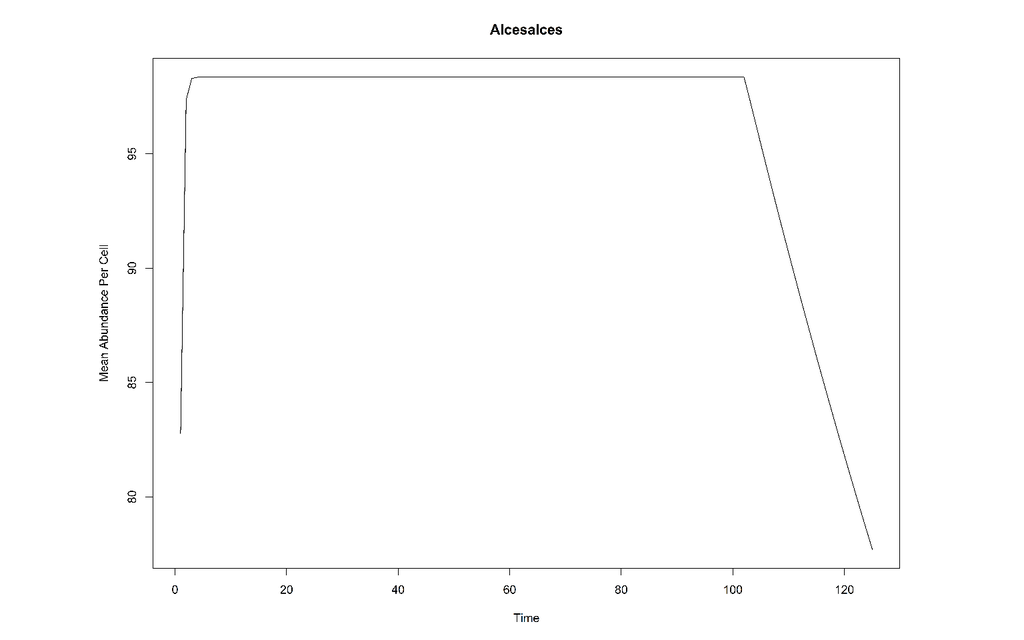

```r
for (species in target_species) {
tiff(file.path(dirout, paste0("MeanAbundancePerCell", species, ".tiff")),
     width = 300, height = 230, units = "mm", res = 1200, compression = "lzw")
# plotting mean abundance per cell
plot(sim$globals[[species]][["mean_abundance"]],
     type = "l",
     xlab = "Time", ylab = "Mean Abundance Per Cell", main = species)
dev.off()
}
```

We can also save a .csv file with the total number of individuals that was saved as a global variable for each time step, being the sum of all individuals in the complete landscape.

```r
# create a list to store dfs
df_list <- list()
# save total number of individuals (TNIND) in the landscape for each species
for (species in target_species) {
  df_list[[species]] <-  as.data.frame(sim$globals[[species]]$n_abundance)%>%
    mutate(#Scenario = scenario,
      biome = target_biome,
      region = target_region,
      species = species,
      timestep = row_number()) %>%
    rename("TNIND" = "sim$globals[[species]]$n_abundance")
}
# combine all species together
TNIND_yr <- do.call(rbind, df_list)
# save csv file with TNIND
write.csv(TNIND_yr, file = file.path(dirout, paste0("TNIND_yr_", runname, ".csv")), row.names = FALSE)
```

## Step 10 - Settings file

We can save a simulation summary with an overall description of the simulation and a species specific report to allow us to revisit simualtion parameters and set up in the future.

```r
sink(file.path(dirout, "simulationSettings.txt"))
# write overall summary of simulation
cat("### Overall Simulation Summary ###\n")
print(summary(sim))
cat("\n========================================\n\n")
# write a specific summary for the species
for (species in target_species) {
  cat("\nSummary for:", species, "\n")
  print(summary(sim[[species]]))
  cat("\n--------------------------------\n")
}

sink()
```

# Model results

In this example, we saved the simulation results in raster format, for the reproduction rate, dispersal change and abundance, allowing us to produce multiple output metrics and maps.

## Reproduction Rate (timestep 101)

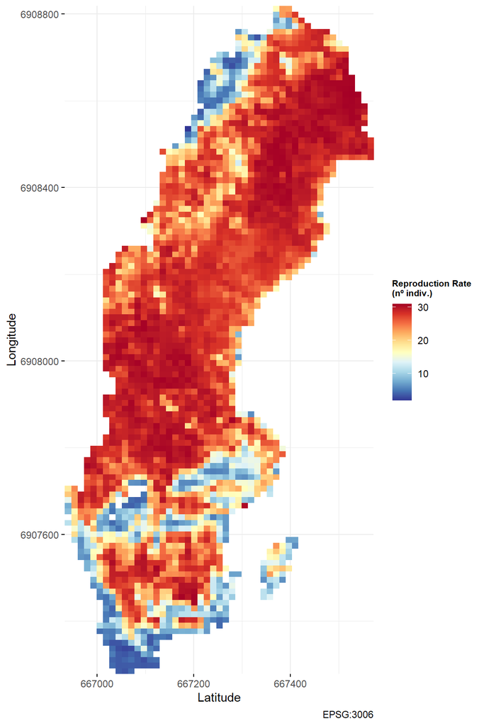

```r
library(RColorBrewer)
library(patchwork)

# Load rasters
repRate101 <- rast(list.files(dirout, pattern = paste0("101_", target_species, "_reproductionRate\\.tif"), full.names = TRUE))
# Convert to dataframes
repRate101_df <- as.data.frame(repRate101, xy = TRUE)

# plot timestep 101
repRate101_plot <- ggplot() +
  geom_raster(data = repRate101_df, aes(x = x, y = y, fill = lyr1)) +
  scale_fill_gradientn(colors = rev(brewer.pal(11, "RdYlBu")), na.value = "transparent", name = "Reproduction Rate\n(nº indiv.)") +
  scale_x_continuous(expand = c(0,0)) +
  scale_y_continuous(expand = c(0,0)) +
  labs(x = "Latitude", y = "Longitude", caption = "EPSG:3006") +
  theme_minimal() +
  theme(legend.title = element_text(size = 8, face = "bold", vjust = 0.9),
        legend.position = "right",
        legend.box.background = element_rect(fill = "white", color = NA),
        axis.ticks = element_line(color = "black", linewidth = 0.5),
        plot.title = element_text(face ="italic", size = 10, hjust = 0.5))
repRate101_plot
```

## Dispersal change (timestep 125)

Dispersal change was defined as the difference between the number of individuals in a cell after dispersal and the number of individuals before dispersal, in the current timestep, which allows us to quantify how many individuals left and entered each cell in each timestep.

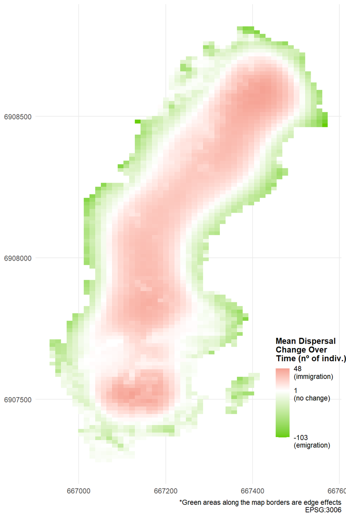

```r
# list dispersal change files
dispersal_files <- rast(list.files(path = dirout,
                                pattern = paste0("125_", target_species, "_dispersal_change\\.tif"),
                                full.names = TRUE))
dispersal_df <- as.data.frame(dispersal_files, xy = TRUE)

# plot dispersal change
dispersal_plot <- ggplot() +
  geom_raster(data = dispersal_df, aes(x = x, y = y, fill = lyr1)) +
  labs(x = "Latitude", y = "Longitude", caption = "*Green areas along the map borders are edge effects\nEPSG:3006") +
  scale_fill_gradient2(low = "chartreuse3", mid = "white", high = "firebrick3", midpoint = 0,
                       breaks = c(min(dispersal_df$lyr1, na.rm = TRUE),
                                  mean(dispersal_df$lyr1, na.rm = TRUE),
                                  max(dispersal_df$lyr1, na.rm = TRUE)),
                       labels = c(paste0(round(min(dispersal_df$lyr1, na.rm = TRUE)), "\n(emigration)"),
                                  paste(round(mean(dispersal_df$lyr1, na.rm = TRUE)), "\n(no change)"),
                                  paste(round(max(dispersal_df$lyr1, na.rm = TRUE)), "\n(immigration)")),
                       name = "Mean Dispersal\nChange Over\nTime (nº of indiv.)") +
  theme_minimal() +
  theme(legend.title = element_text(size = 10, face = "bold", vjust = 1.9),
        legend.position = c(0.9, 0.2),
        legend.text = element_text(vjust = 0.8),
        # remove background and line from legend box
        legend.box.background = element_rect(fill = NA, color = NA),
        # remove grid lines
        panel.background = element_blank(),
        panel.grid.minor = element_blank(),
        # remove coordinates and axis labels
        axis.title = element_blank())
dispersal_plot
```

## Abundance (timestep 125)

Since abundance at each timestep is influenced by both reproduction and dispersal changes, we now want to examine the abundance rasters generated for our target species. By focusing on the abundance in the final timestep, we can evaluate how the species has responded to changes in the landscape.

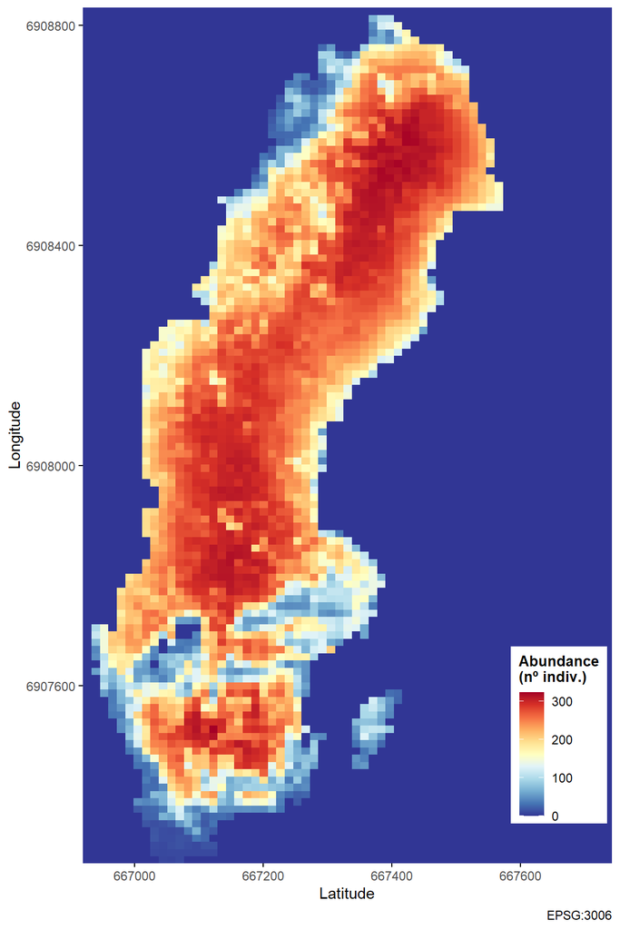

```r
# find raster for sps final abundance
abund125 <- rast(list.files(dirout,
                            pattern = paste0("125_", target_species, "_abundance\\.tif"), full.names = TRUE))
# convert to dataframe
abundance125_df <- as.data.frame(abund125, xy = TRUE)

# plot final abundance values for sps
abundance125_plot <- ggplot() +
  geom_raster(data = abundance125_df, aes(x = x, y = y, fill = lyr1)) +
  scale_fill_gradientn(colors = rev(brewer.pal(11, "RdYlBu")), na.value = "transparent", name = "Abundance\n(nº indiv.)") +
  #scale_fill_viridis_c(name = "Nº of\nindividuals", na.value = NA) +
  # remove space between axis and plot area
  scale_x_continuous(expand = c(0,0)) +
  scale_y_continuous(expand = c(0,0)) +
  labs(x = "Latitude", y = "Longitude", caption = "EPSG:3006") +
  theme_minimal() +
  theme(legend.title = element_text(size = 10, face = "bold", vjust = 0.9),
        legend.position = c(0.9, 0.15),
        legend.box.background = element_rect(fill = "white", color = NA),
        axis.ticks = element_line(color = "black", linewidth = 0.5))
abundance125_plot
```

## Proportion of abundance change

We can also quantify the change in abundance for each species using the model output rasters.

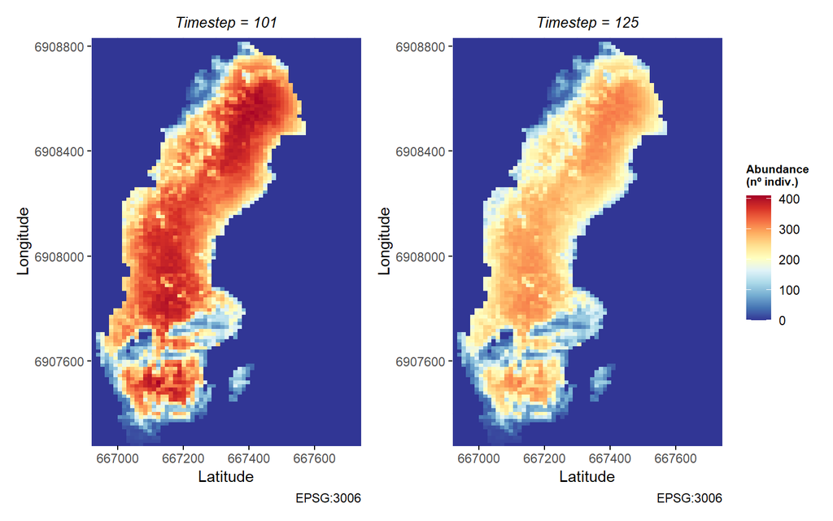

```r
library(RColorBrewer)
library(patchwork)

# Load rasters
abund101 <- rast(list.files(dirout, pattern = paste0("101_", target_species, "_abundance\\.tif"), full.names = TRUE))
# Convert to dataframes
abund101_df <- as.data.frame(abund101, xy = TRUE)

# find global min and max values for the combined color scale
common_limits <- range(c(abund101_df$lyr1, abundance125_df$lyr1), na.rm = TRUE)
# define common scale
common_fill_scale <- scale_fill_gradientn(colors = rev(brewer.pal(11, "RdYlBu")),
                                          limits = common_limits,
                                          na.value = "transparent",
                                          name = "Abundance\n(nº indiv.)")

# plot timestep 101
abund101_plot <- ggplot() +
  geom_raster(data = abund101_df, aes(x = x, y = y, fill = lyr1)) +
  common_fill_scale +  # Apply common color scale
  scale_x_continuous(expand = c(0,0)) +
  scale_y_continuous(expand = c(0,0)) +
  labs(x = "Latitude", y = "Longitude", caption = "EPSG:3006", title = "Timestep = 101") +
  theme_minimal() +
  theme(legend.title = element_text(size = 8, face = "bold", vjust = 0.9),
        legend.position = "right",
        legend.box.background = element_rect(fill = "white", color = NA),
        axis.ticks = element_line(color = "black", linewidth = 0.5),
        plot.title = element_text(face ="italic", size = 10, hjust = 0.5))
abundance125_plot <- ggplot() +
  geom_raster(data = abundance125_df, aes(x = x, y = y, fill = lyr1)) +
   common_fill_scale +  # Apply common color scale
  # remove space between axis and plot area
  scale_x_continuous(expand = c(0,0)) +
  scale_y_continuous(expand = c(0,0)) +
  labs(x = "Latitude", y = "Longitude", caption = "EPSG:3006", title = "Timestep = 125") +
  theme_minimal() +
  theme(legend.title = element_text(size = 8, face = "bold", vjust = 0.9),
        legend.position = c(0.9, 0.15),
        legend.box.background = element_rect(fill = "white", color = NA),
        axis.ticks = element_line(color = "black", linewidth = 0.5),
        plot.title = element_text(face ="italic", size = 10, hjust = 0.5))
# combine plots
abund101_plot + abundance125_plot + plot_layout(guides = "collect")
```

By comparing abundance rasters from the final and initial timesteps (after the burn-in period), we can calculate the proportional change in abundance for each species. This is done using the following formula:

$Prop.\ Abundance\ Change\ = \frac{Abundance\ t = 125\ -\ abundance\ t = 101} {abundance\ t = 101}$

providing a clear measure of how much a species’ abundance has changed over time.

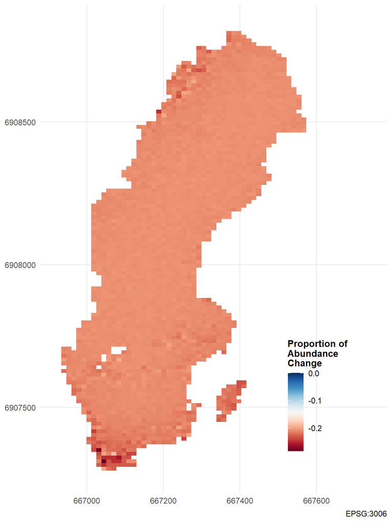

```r
# go back for the final timestep abundance raster for the sps
abundance125_df <- abundance125_df %>%
  # add timestep info
  mutate(timestep = 125)

# get 1st timestep after the burn-in
abund101 <- rast(list.files(dirout,
                              pattern = paste0("101_", target_species, "_abundance\\.tif"), full.names = TRUE))
# convert to dataframe
  abundance101_df <- as.data.frame(abund101, xy = TRUE) %>%
  # add timestep info
  mutate(timestep = 101)

# bind dataframes from both timesteps needed
abund_change <- rbind(abundance101_df, abundance125_df) %>%
  # rename to more understandable
  rename("abundance" = lyr1) %>%
  # calculate the proportion of abundance change
  mutate(abund_change_prop = (abundance - abundance[timestep == 101])/abundance[timestep == 101])

library(RColorBrewer)
# proportion of abundance change plot
prop_abund_change <- ggplot() +
  geom_raster(data = abund_change, aes(x = x, y = y, fill = abund_change_prop)) +
  scale_fill_gradientn(colors = brewer.pal(11, "RdBu"), na.value = "transparent") +
  labs(x = "Latitude", y = "Longitude", fill = "Proportion of\nAbundance\nChange", caption = "EPSG:3006") +
  theme_minimal() +
  theme(legend.title = element_text(size = 10, face = "bold", vjust = 0.9), legend.position = c(0.8, 0.2),
        # remove background and line from legend box
        legend.box.background = element_rect(fill = NA, color = NA),
        # remove grid lines
        panel.background = element_blank(), panel.grid.minor = element_blank(),
        # remove coordinates and axis labels
        axis.title = element_blank())
prop_abund_change
```

## Average dispersal change

To analyze how a species has moved in our landscape, over time, we can aggregate and visualize dispersal patterns using the produced dispersal change rasters. By selecting all relevant dispersal change rasters for our target species (after the burn-in and until the simulation’s last timestep) and computing their average, we can generate a spatial representation of the target species movement trends. This allows us to identify areas where the species is more likely to emigrate (where more individuals tend to leave) and areas where it is more likely to immigrate (where more individuals tend to arrive).

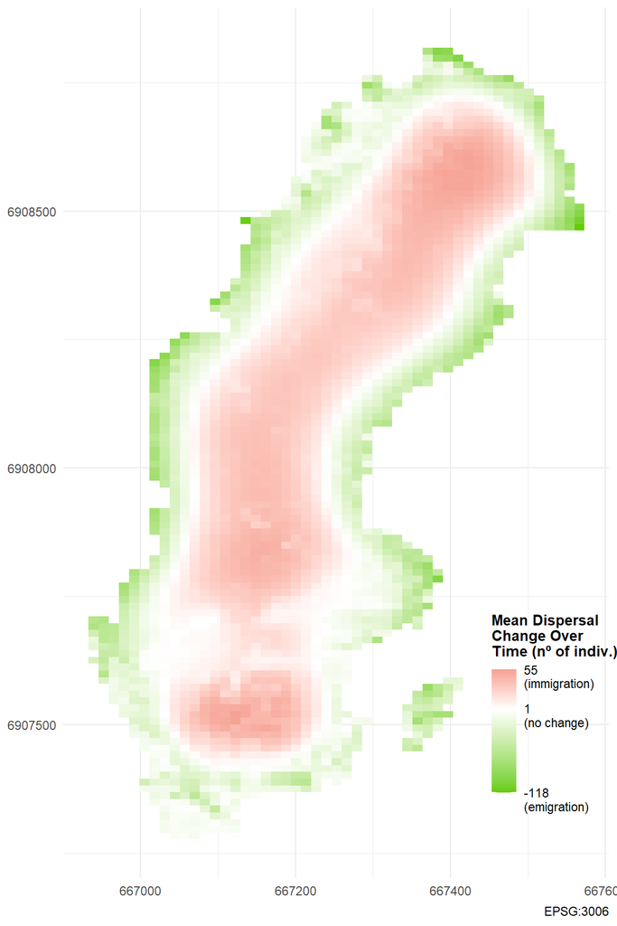

```r
# list dispersal change files
dispersal_files <- list.files(path = dirout,
                            pattern = paste0(".*(10[1-9]|11[0-9]|12[0-5])_", target_species, "_dispersal_change\\.tif"),
                            full.names = TRUE)
# read rasters & stack them
dispersal_stack <- c(rast(dispersal_files))
# average rasters across ALL years
dispersal_avg <- mean(dispersal_stack, na.rm = TRUE)
# transform into dataframe
dispersal_df <- as.data.frame(dispersal_avg, xy = TRUE)

# plot dispersal change
avg_dispersal_plot <- ggplot() +
  geom_raster(data = dispersal_df, aes(x = x, y = y, fill = mean)) +
  labs(x = "Latitude", y = "Longitude", caption = "EPSG:3006") +
  scale_fill_gradient2(low = "chartreuse3", mid = "white", high = "firebrick3", midpoint = 0,
                       breaks = c(min(dispersal_df$mean, na.rm = TRUE),
                                  mean(dispersal_df$mean, na.rm = TRUE),
                                  max(dispersal_df$mean, na.rm = TRUE)),
                       labels = c(paste0(round(min(dispersal_df$mean, na.rm = TRUE)), "\n(emigration)"),
                                  paste(round(mean(dispersal_df$mean, na.rm = TRUE)), "\n(no change)"),
                                  paste(round(max(dispersal_df$mean, na.rm = TRUE)), "\n(immigration)")),
                       name = "Mean Dispersal\nChange Over\nTime (nº of indiv.)") +
  theme_minimal() +
  theme(legend.title = element_text(size = 10, face = "bold", vjust = 1.9),
        legend.position = c(0.9, 0.2),
        legend.text = element_text(vjust = 0.8),
        # remove background and line from legend box
        legend.box.background = element_rect(fill = NA, color = NA),
        # remove grid lines
        panel.background = element_blank(),
        Panel.grid.minor = element_blank(),
        # remove coordinates and axis labels
        axis.title = element_blank())
avg_dispersal_plot
```

# Model Validation

To determine whether the model accurately represents the behavior of the real system being modeled, we can compare the estimated abundance for our target species with an external source dataset. In this case, we used the dataset from [Santini et. al 2022](https://onlinelibrary.wiley.com/doi/full/10.1111/geb.13476) and a user defined function, which takes as inputs:

- targetspecies: Vector of species names for which the validation will be performed
- independentDensity: dataframe containing species density estimates from an Santini et. al 2022
- estimatedDensity: dataframe containing species abundance data derived from the model output
- spData: dataframe with species traits (with ModellingRes) to calculate density from abundance

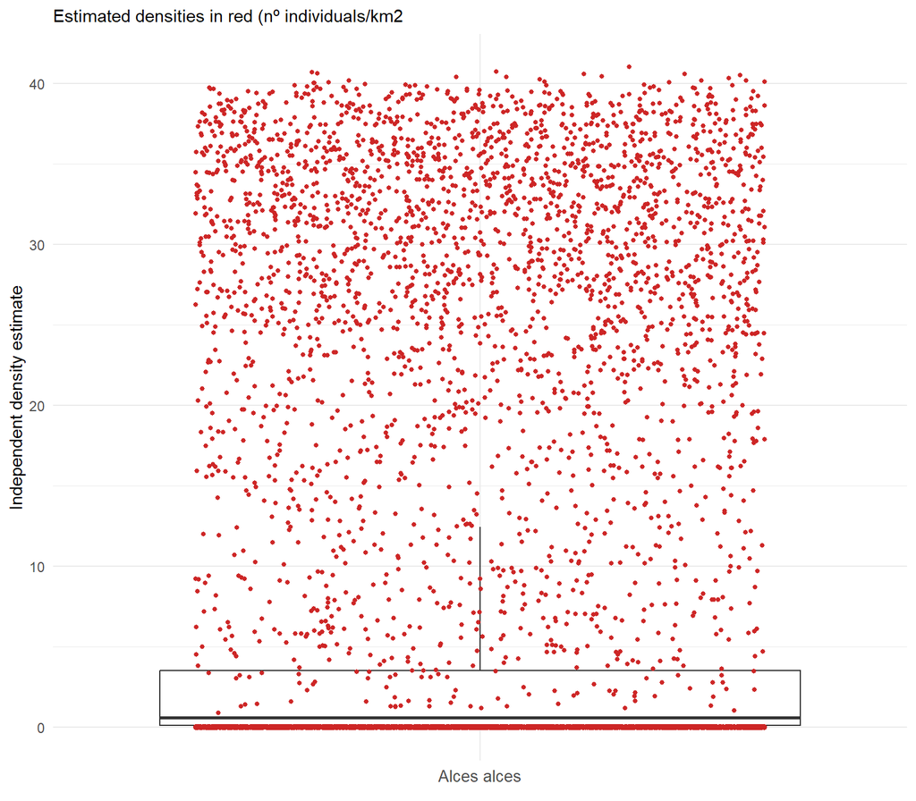

```r
# find raster for timestep to validate
abund101 <- rast(list.files(dirout,
                            pattern = paste0("101_", target_species, "_abundance\\.tif"), full.names = TRUE))
# convert to dataframe
abundance101_df <- as.data.frame(abund101, xy = TRUE)
# aplly model validate function
validationList <- validateModel_1sps(# target species to validate
                                     targetspecies = target_species,
                                     # target sps abundance estimates from external source
                                     independentDensity = santini2022,
                                     # target sps abundance estimated with our model
                                     estimatedDensity = abundance101_df,
                                     # target sps trait data
                                     spData = spData)
# replace sps names to better looking
validationList <- lapply(validationList, function(df) {df$species <- names_replace[df$species]; return(df) })
# plot model validation
validation_plot <- ggplot(validationList$independentDensity, aes(species)) +
  geom_boxplot(aes(ymin = lw95, lower = lw75, middle = meanDensity, upper = up75, ymax = up95), stat = "identity") +
  geom_point(data = validationList$estimatedDensity,
             aes(x = species, y = estimatedDensity), color = "firebrick3", position = "jitter", size = 1) +
  labs(y = "Independent density estimate", x = element_blank(),
       #title = "Model validation",
       subtitle =  "Estimated densities in red (nº individuals/km2",
       #caption = "performed for timestep 100"
       ) +
  theme_minimal() +
  theme(plot.caption = element_text(size = 8),
        axis.text.x = element_text(size = 10))
validation_plot
```